# Exercise 9.2

Eduard, Felix, Linus & Noah

2024-02-09

# Puzzle

**Mediation**

Baron Kenny have provided a popular method to implement mediation analysis.

Declare a design with a mediation process and possible violations of sequential ignorability, governed by some parameters `k`.

Demonstrate under what conditions estimates using the Baron-Kenny procedure are misleading.

# Idea

## Mediator

What is the causal mechanism between X and Y?

*``In general, a given variable may be said to function as a mediator to the extent that it accounts for the relation between the predictor and the criterion.’’* ([Baron & Kenny 1986, 1176](https://psycnet.apa.org/doi/10.1037/0022-3514.51.6.1173))

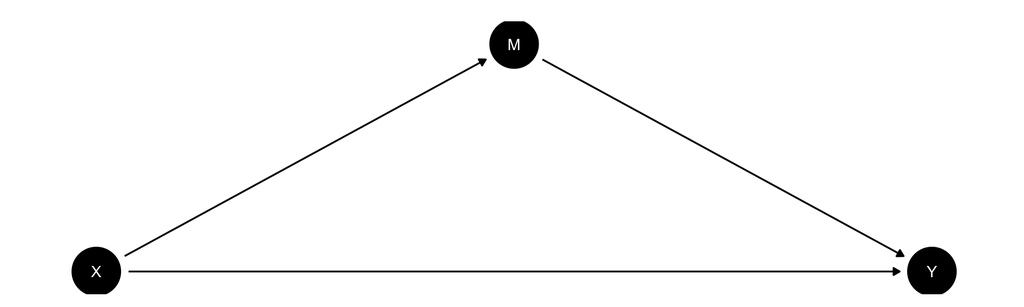

## Sequential ignorability

**Key assumption with two parts:** (see [Imai et al. 2010, 310](https://doi.org/10.1037/a0020761))

1. conditional on the observed pretreatment covariates, the treatment is independent of all potential values of the outcome and mediating variables
2. the observed mediator is independent of all potential outcomes given the observed treatment and pretreatment covariates

## Violation of sequential ignorability

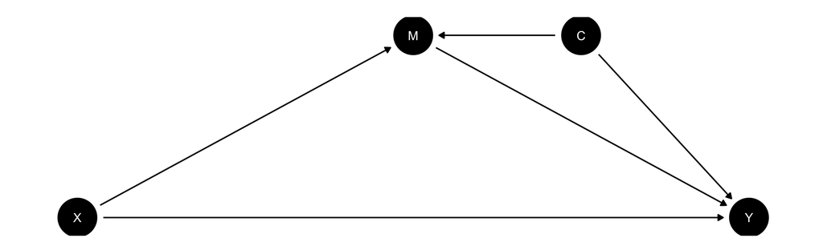

## Baron-Kenny approach

Based on *linear structural equation model* (LSEM)

Effect of treatment on outcome:
$$Y_i = \alpha_1 + \beta_1T_i + \varepsilon_{i1} \tag{1}$$

Effect of treatment on mediator:
$$M_i = \alpha_2 + \beta_2T_i + \varepsilon_{i2} \tag{2}$$

Effect of treatment on outcome conditioned on the mediator:
$$Y_i = \alpha_3 + \beta_3T_i + \gamma M_i + \varepsilon_{i3} \tag{3}$$

# Solution

## Parameter

```r
# parameter of unobserved confounder C
k <- 0

# some other parameters
N <- 200
a <- 5
b <- 0.7
d <- 0.3
rho <- 0
```

## Model

```r
model_mediate <-
  declare_model(

    # units and shocks
    N = N,
    e1 = rnorm(N),
    e2 = rnorm(
      n = N,
      mean = rho * e1,
      sd = sqrt(1 - rho ^ 2)
    ),

    # confounding variable
    C = rnorm(N),

    # mediator
    potential_outcomes(
      M ~ 1 * (a * Z + k * C + e1 > 0)),

    # outcome
    potential_outcomes(
      Y ~ d * Z + b * M + k * C + e2,
      conditions = list(M = 0:1, Z = 0:1)
    )
  )
```

## Potential Outcomes

```r
model_mediate() |>
  select(contains("_Z_")) |>
  head() |>
  kable(digits = 2) |>
  kable_styling(font_size = 20)
```

| M_Z_0 | M_Z_1 | Y_M_0_Z_0 | Y_M_1_Z_0 | Y_M_0_Z_1 | Y_M_1_Z_1 |
| --- | --- | --- | --- | --- | --- |
| 0 | 1 | -1.47 | -0.77 | -1.17 | -0.47 |
| 0 | 1 | -0.51 | 0.19 | -0.21 | 0.49 |
| 0 | 1 | 0.03 | 0.73 | 0.33 | 1.03 |
| 1 | 1 | -2.17 | -1.47 | -1.87 | -1.17 |
| 1 | 1 | 0.83 | 1.53 | 1.13 | 1.83 |
| 1 | 1 | 0.71 | 1.41 | 1.01 | 1.71 |

## Inquiry

```r
inquiry_mediate <-

  declare_inquiries(

    direct_Z_Y = mean(M_1_Z_1 - M_1_Z_0),

    direct_Z_M = mean(M_Z_1 - M_Z_0),

    mediated_Z_Y = mean(M_1_Z_1 - M_1_Z_0) - mean(M_0_Z_1 - M_0_Z_0),

    mediated_M_Y = mean(M_1_Z_1 - M_0_Z_1) - mean(M_0_Z_1 - M_0_Z_0)

  )
```

## Assignment & measurement

```r
assignment_mediate <-
  declare_assignment(
    Z = complete_ra(N, prob = 0.5)
  )

measurement_mediate <-
  declare_measurement(
    M = reveal_outcomes(M ~ Z),
    Y = reveal_outcomes(Y ~ M + Z)
  )
```

## Estimators

```r
estimator_Z_Y <-
  declare_estimator(
    Y ~ Z,
    .method = lm_robust,
    label = "First regression"
  )

estimator_Z_M <-
  declare_estimator(
    M ~ Z,
    .method = lm_robust,
    label = "Second regression"
  )

estimator_mediate <-
  declare_estimator(
    Y ~ Z + M,
    .method = lm_robust,
    term = c("Z", "M"),
    label = c("Third regression")
  )
```

## Declare the design

```r
design_mediate <-
  model_mediate +
  #inquiry_mediate +
  assignment_mediate +
  measurement_mediate +
  estimator_Z_Y +
  estimator_Z_M +
  estimator_mediate
```

## Run design once

```r
design_mediate |>
  run_design() |>
  kable(digits = 2) |>
  kable_styling(font_size = 20)
```

| estimator | term | estimate | std.error | statistic | p.value | conf.low | conf.high | df | outcome |
| --- | --- | --- | --- | --- | --- | --- | --- | --- | --- |
| First regression | Z | 0.72 | 0.14 | 5.10 | 0.00 | 0.44 | 1.00 | 198 | Y |
| Second regression | Z | 0.50 | 0.05 | 9.95 | 0.00 | 0.40 | 0.60 | 198 | M |
| Third regression | Z | 0.21 | 0.16 | 1.32 | 0.19 | -0.10 | 0.52 | 197 | Y |
| Third regression | M | 1.03 | 0.18 | 5.70 | 0.00 | 0.67 | 1.38 | 197 | Y |

## Redesign over parameter `k`

```r
redesign_mediate <-
  design_mediate |>
  redesign(k = seq(-1, 1, 0.01))
```

## Diagnose designs

```r
diagnose_mediate <-
  redesign_mediate |>
  diagnose_designs(
    sims = 100,
    bootstrap_sims = 100
  )

diagnosands_mediate <-
  diagnose_mediate |>
  get_diagnosands()
```

## Estimates of M & Z for different levels of `k`

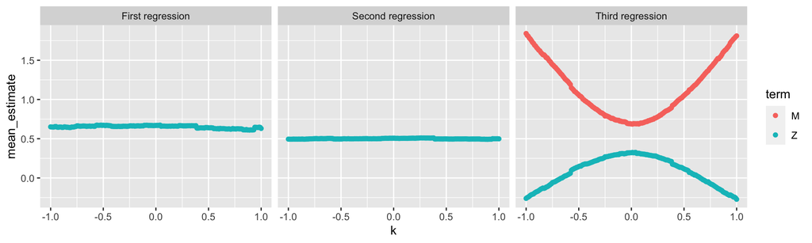

## Standard error of M & Z for different levels of `k`

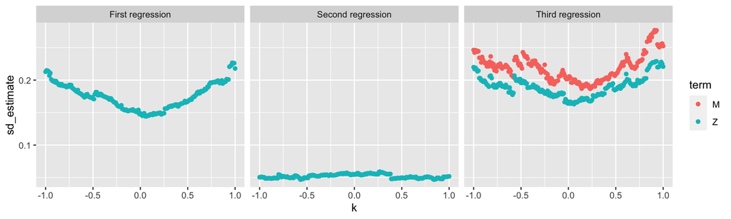